# Ecological models in NIMBLE: Capture-recapture

NIMBLE 2023 Virtual Workshop

NIMBLE Development Team

January 2023

# Agenda

In this module we will cover a variety of distributions and strategies relevant for ecological models. These include:

1. Cormack-Jolly-Seber (CJS) capture-recapture models
2. Multi-state and multi-event capture-recapture models (Hidden Markov Models)
3. Occupancy models
4. Dynamic occupancy models
5. N-mixture models
6. Spatial capture-recapture (SCR) models

# Some resources

Distributions that marginalize over latent states are available for the first five of these in the [`nimbleEcology` (Goldstein et al. 2020)](https://CRAN.R-project.org/package=nimbleEcology) package.

We will focus on the code. For `nimbleEcology`, the math related to the code is summarized in the [package vignette](https://cran.r-project.org/web/packages/nimbleEcology/vignettes/Introduction_to_nimbleEcology.html).

Examples of occupancy, dynamic occupancy, and N-mixture models are given in [*One size does not fit all: Customizing MCMC methods for hierarchical models using NIMBLE* (Ponisio et al. 2020)](https://onlinelibrary.wiley.com/doi/full/10.1002/ece3.6053).

Examples of CJS and HMM are given in [*Efficient Markov chain Monte Carlo sampling for hierarchical hidden Markov models* (Turek et al. 2016)](https://link.springer.com/article/10.1007/s10651-016-0353-z).

Examples of SCR are given in [*Efficient Estimation of Large-Scale Spatial Capture-Recapture Models* (Turek et al. 2020, bioRxiv preprint)](https://www.biorxiv.org/content/10.1101/2020.05.07.081182v1). Code for these is (mostly) in the Appendix but is not yet curated into a package.

Some SCR steps are given in [*A local evaluation of the individual state-space to scale up Bayesian spatial capture-recapture* (Milleret et al. 2019). Ecology and Evolution 9:352–363](https://onlinelibrary.wiley.com/doi/full/10.1002/ece3.4751)

We will go through some of the methods and results of these papers.

# Cormack-Jolly-Seber (CJS) capture-recapture

Dipper example:

- 294 Dippers monitored 1981-1987.
- One of the most classic capture-recapture teaching datasets ever.
- Thanks to Olivier Gimenez and Daniel Turek for Dipper examples from previous workshops.

# Load the data

```r
dipper_example_dir <- here::here("content", "examples","Dipper")
dipper <- read.csv(file.path(dipper_example_dir,"dipper.csv"))
y <- as.matrix(dipper[ , 1:7])
first <- apply(y, 1, function(x) min(which(x !=0)))
y <- y[ first != 7, ]
y_orig <- y # Keep an "original version" for use below
head(y)
```

```
##      year_1981 year_1982 year_1983 year_1984 year_1985 year_1986 year_1987
## [1,]         1         1         1         1         1         1         0
## [2,]         1         1         1         1         1         0         0
## [3,]         1         1         1         1         0         0         0
## [4,]         1         1         1         1         0         0         0
## [5,]         1         1         0         1         1         1         0
## [6,]         1         1         0         0         0         0         0
```

# Dipper example: Most basic version

- Data for one individual are a capture history: `y[i, 1:T]` = $[1, 0, 1, 1, 0, 0]$.
- First entry must be `1` because CJS conditions on first capture.
- True alive/dead (latent) states: `z[i, 1:T]` = $[1, 1, 1, 1, (0 | 1), (0|1)]$.
- A basic way to write this in model code with individual latent states is:

```r
dipper_code_basic <- nimbleCode({
  phi ~ dunif(0, 1) # survival prior
  p ~ dunif(0, 1)   # detection prior
  # likelihood
  for (i in 1:N){
    z[i,first[i]] <- 1
    for (t in (first[i]+1):T){
      z[i,t] ~ dbern(phi * z[i,t-1]) # z = 0 for dead, 1 for alive
      y[i,t] ~ dbern(p * z[i,t])     # y = 0 for not-observed, 1 for observed
    }}
  })
```

# Inputs for basic version

```r
first <- apply(y_orig, 1, function(x) min(which(x !=0)))
dipper_constants <- list(N = nrow(y),
                         T = ncol(y_orig),
                         first = first)
dipper_data <- list(y = y_orig)   # 0s and 1s
zinits <- y_orig                  # 0s and 1s
dipper_inits <- function() list(phi = runif(1,0,1),
                                  p = runif(1,0,1),
                                  z = zinits)
head(zinits)
```

```
##      year_1981 year_1982 year_1983 year_1984 year_1985 year_1986 year_1987
## [1,]         1         1         1         1         1         1         0
## [2,]         1         1         1         1         1         0         0
## [3,]         1         1         1         1         0         0         0
## [4,]         1         1         1         1         0         0         0
## [5,]         1         1         0         1         1         1         0
## [6,]         1         1         0         0         0         0         0
```

# Run basic version

```r
samples <- nimbleMCMC(dipper_code_basic, dipper_constants, dipper_data,
                      dipper_inits(), samplesAsCodaMCMC = TRUE)
```

```
## Defining model
```

```
## Building model
```

```
## Setting data and initial values
```

```
## Running calculate on model
##   [Note] Any error reports that follow may simply reflect missing values in model variables.
```

```
## Checking model sizes and dimensions
```

```
##   [Note] This model is not fully initialized. This is not an error.
##          To see which variables are not initialized, use model$initializeInfo().
##          For more information on model initialization, see help(modelInitialization).
```

```
## Checking model calculations
```

```
## [Note] Infinite values were detected in model variable: logProb_z.
```

```
## Compiling
##   [Note] This may take a minute.
##   [Note] Use 'showCompilerOutput = TRUE' to see C++ compilation details.
```

```
## running chain 1...
```

```
## warning: problem initializing stochastic node z[12, 3]: logProb is -Inf.
## warning: problem initializing stochastic node z[13, 3]: logProb is -Inf.
## warning: problem initializing stochastic node z[94, 5]: logProb is -Inf.
## warning: problem initializing stochastic node z[150, 6]: logProb is -Inf.
## warning: problem initializing stochastic node z[5, 4]: logProb is -Inf.
## warning: problem initializing stochastic node z[31, 5]: logProb is -Inf.
## warning: problem initializing stochastic node z[151, 7]: logProb is -Inf.
## warning: problem initializing stochastic node z[152, 7]: logProb is -Inf.
## |-------------|-------------|-------------|-------------|
## |-------------------------------------------------------|
```

# Dipper basic model: results

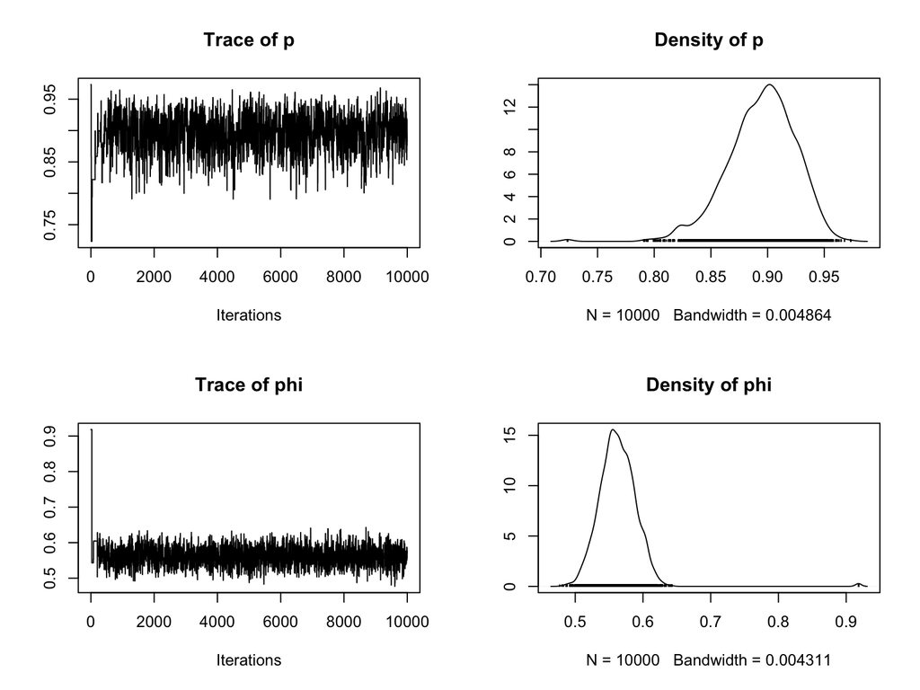

```r
plot(samples)
```

# Dipper basic model: results

- We got lucky and got away with invalid initial values for `z`.
- These were set to `y`, so they had dead birds come alive again, giving the logProb warnings.
- Actually, we shouldn’t need to sample latent state of birds known to be alive!

# Dipper basic model: slightly better version

- `z[i, t]` until time of last capture can be provided as data.
- `z[i, t]` after last capture need to be sampled by MCMC as latent states.

```r
zinits <- y_orig
y <- y_orig
zdata <- matrix(NA, nrow = nrow(y), ncol = ncol(y))
for(i in 1:nrow(zinits)) {
  known_alive <- range(which(zinits[i,] == 1))
  zinits[i, known_alive[1] : known_alive[2] ] <- NA
  zdata[i, known_alive[1] : known_alive[2] ] <- 1
}
head(zinits)
```

```
##      year_1981 year_1982 year_1983 year_1984 year_1985 year_1986 year_1987
## [1,]        NA        NA        NA        NA        NA        NA         0
## [2,]        NA        NA        NA        NA        NA         0         0
## [3,]        NA        NA        NA        NA         0         0         0
## [4,]        NA        NA        NA        NA         0         0         0
## [5,]        NA        NA        NA        NA        NA        NA         0
## [6,]        NA        NA         0         0         0         0         0
```

```r
head(zdata)
```

```
##      [,1] [,2] [,3] [,4] [,5] [,6] [,7]
## [1,]    1    1    1    1    1    1   NA
## [2,]    1    1    1    1    1   NA   NA
## [3,]    1    1    1    1   NA   NA   NA
## [4,]    1    1    1    1   NA   NA   NA
## [5,]    1    1    1    1    1    1   NA
## [6,]    1    1   NA   NA   NA   NA   NA
```

# Run slightly better version:

```r
dipper_data$z <- zdata
dipper_inits <- function() list(phi = runif(1,0,1),
                                p = runif(1,0,1),
                                z = zinits)
samples <- nimbleMCMC(dipper_code_basic, dipper_constants, dipper_data,
                      dipper_inits(), samplesAsCodaMCMC = TRUE)
```

```
## Defining model
```

```
## Building model
```

```
## Setting data and initial values
```

```
## Running calculate on model
##   [Note] Any error reports that follow may simply reflect missing values in model variables.
```

```
## Checking model sizes and dimensions
```

```
##   [Note] This model is not fully initialized. This is not an error.
##          To see which variables are not initialized, use model$initializeInfo().
##          For more information on model initialization, see help(modelInitialization).
```

```
## Checking model calculations
```

```
## Compiling
##   [Note] This may take a minute.
##   [Note] Use 'showCompilerOutput = TRUE' to see C++ compilation details.
```

```
## running chain 1...
```

```
## |-------------|-------------|-------------|-------------|
## |-------------------------------------------------------|
```

```r
# This will run a bit faster.
```

# Dipper example: Conventional more general version as HMM

- Start to set up a general hidden Markov model using categorical distributions.
- y: 1 = not-detected, 2 = detected.
- z: 1 = alive, 2 = dead. (This flips the order from above, but in often “dead” is the last state.)
- Modified from Gimenez et al. capture-recapture workshop

```r
dipper_code_dcat <- nimbleCode({
  phi ~ dunif(0, 1) # prior survival
  p ~ dunif(0, 1) # prior detection
  # likelihood
  gamma[1,1:2] <- c(phi, 1-phi)      # Pr(alive t -> alive t+1), Pr(alive t -> dead t+1)
  gamma[2,1:2] <- c(0, 1)            # Pr(dead t -> alive t+1), Pr(dead t -> dead t+1)
  delta[1:2] <- c(1, 0)              # Pr(alive t = 1) = 1, Pr(dead t = 1) = 0
  omega[1,1:2] <- c(1 - p, p)        # Pr(alive t -> non-detected t), Pr(alive t -> detected t)
  omega[2,1:2] <- c(1, 0)            # Pr(dead t -> non-detected t), Pr(dead t -> detected t)
  for (i in 1:N){
    z[i,first[i]] ~ dcat(delta[1:2]) # Illustrates initial state probabilities
    for (j in (first[i]+1):T){
      z[i,j] ~ dcat(gamma[z[i,j-1], 1:2])
      y[i,j] ~ dcat(omega[z[i,j], 1:2])
    }
  }
})
```

# Re-code data to work as indices for categorical distribution

```r
dipper_data$y <- y_orig
dipper_data$y <- dipper_data$y + 1 # 1 = unobserved. 2 = observed.
zinits_dcat <- zinits
zinits_dcat[ zinits_dcat == 0] <- 2 # 1 = alive. 2 = dead.
head(dipper_data$y)
```

```
##      year_1981 year_1982 year_1983 year_1984 year_1985 year_1986 year_1987
## [1,]         2         2         2         2         2         2         1
## [2,]         2         2         2         2         2         1         1
## [3,]         2         2         2         2         1         1         1
## [4,]         2         2         2         2         1         1         1
## [5,]         2         2         1         2         2         2         1
## [6,]         2         2         1         1         1         1         1
```

```r
head(dipper_data$z)  # inits and data for z complement each other
```

```
##      [,1] [,2] [,3] [,4] [,5] [,6] [,7]
## [1,]    1    1    1    1    1    1   NA
## [2,]    1    1    1    1    1   NA   NA
## [3,]    1    1    1    1   NA   NA   NA
## [4,]    1    1    1    1   NA   NA   NA
## [5,]    1    1    1    1    1    1   NA
## [6,]    1    1   NA   NA   NA   NA   NA
```

```r
head(zinits_dcat)
```

```
##      year_1981 year_1982 year_1983 year_1984 year_1985 year_1986 year_1987
## [1,]        NA        NA        NA        NA        NA        NA         2
## [2,]        NA        NA        NA        NA        NA         2         2
## [3,]        NA        NA        NA        NA         2         2         2
## [4,]        NA        NA        NA        NA         2         2         2
## [5,]        NA        NA        NA        NA        NA        NA         2
## [6,]        NA        NA         2         2         2         2         2
```

# Run categorical version:

```r
dipper_inits <- function() list(phi = runif(1,0,1),
                                p = runif(1,0,1),
                                z = zinits_dcat)
samples <- nimbleMCMC(dipper_code_dcat, dipper_constants, dipper_data,
                      dipper_inits(), samplesAsCodaMCMC = TRUE)
```

```
## Defining model
```

```
## Building model
```

```
## Setting data and initial values
```

```
## Running calculate on model
##   [Note] Any error reports that follow may simply reflect missing values in model variables.
```

```
## Checking model sizes and dimensions
```

```
## Checking model calculations
```

```
## Compiling
##   [Note] This may take a minute.
##   [Note] Use 'showCompilerOutput = TRUE' to see C++ compilation details.
```

```
## running chain 1...
```

```
## |-------------|-------------|-------------|-------------|
## |-------------------------------------------------------|
```

# Results from categorical version:

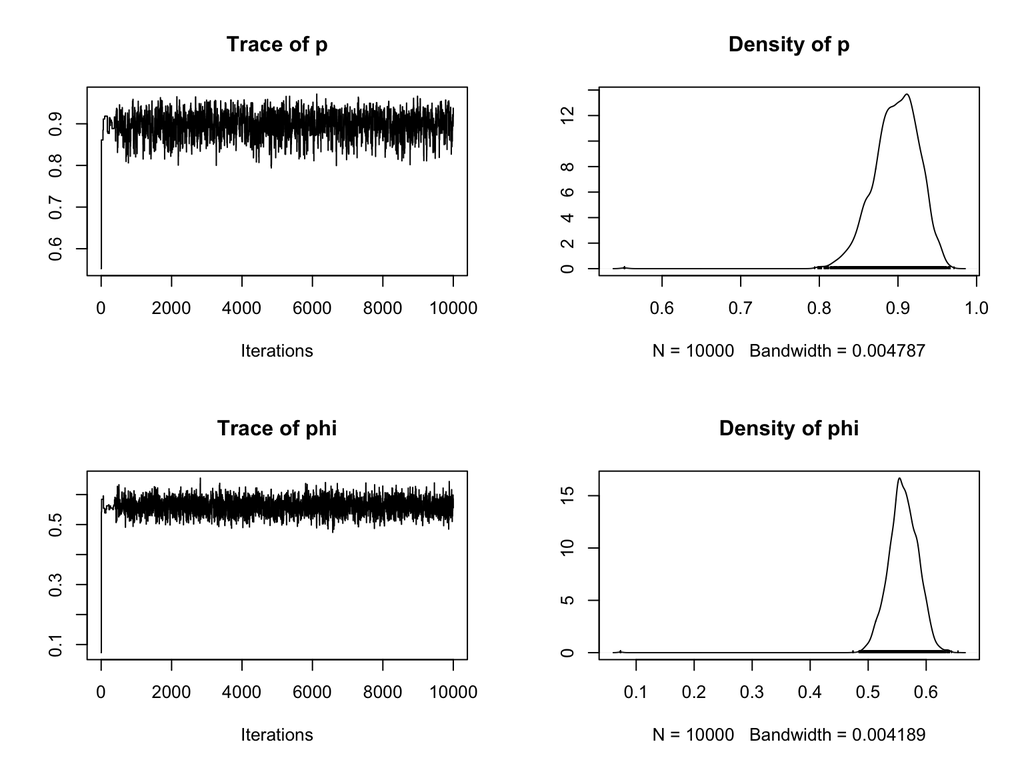

```r
plot(samples)
```

# Dipper example: use dCJS marginal distribution

- `nimbleEcology` alternative way to write this:

```r
dipper_code_dCJS <- nimbleCode({
  phi ~ dunif(0, 1) # survival prior
  p ~ dunif(0, 1)   # detection prior
  # likelihood
  for (i in 1:N){
    y[i, first[i]:T] ~ dCJS_ss(probSurvive=phi, probCapture=p, len=T-first[i]+1)
  }
})
```

- `_ss` indicates that both `probSurvive` and `probCapture` are scalars.

# Run the dCJS version

```r
dipper_inits <- function() list(phi = runif(1,0,1),
                                p = runif(1,0,1))
dipper_data$z <- NULL   # No latent states.
dipper_data$y <- y_orig # Back to 0 = unobserved, 1 = observed
samples <- nimbleMCMC(dipper_code_dCJS, dipper_constants, dipper_data,
                      dipper_inits(), samplesAsCodaMCMC = TRUE)
```

```
## Defining model
```

```
## Building model
```

```
## Setting data and initial values
```

```
## Running calculate on model
##   [Note] Any error reports that follow may simply reflect missing values in model variables.
```

```
## Checking model sizes and dimensions
```

```
## Checking model calculations
```

```
## Compiling
##   [Note] This may take a minute.
##   [Note] Use 'showCompilerOutput = TRUE' to see C++ compilation details.
```

```
## running chain 1...
```

```
## |-------------|-------------|-------------|-------------|
## |-------------------------------------------------------|
```

# See CJS version results

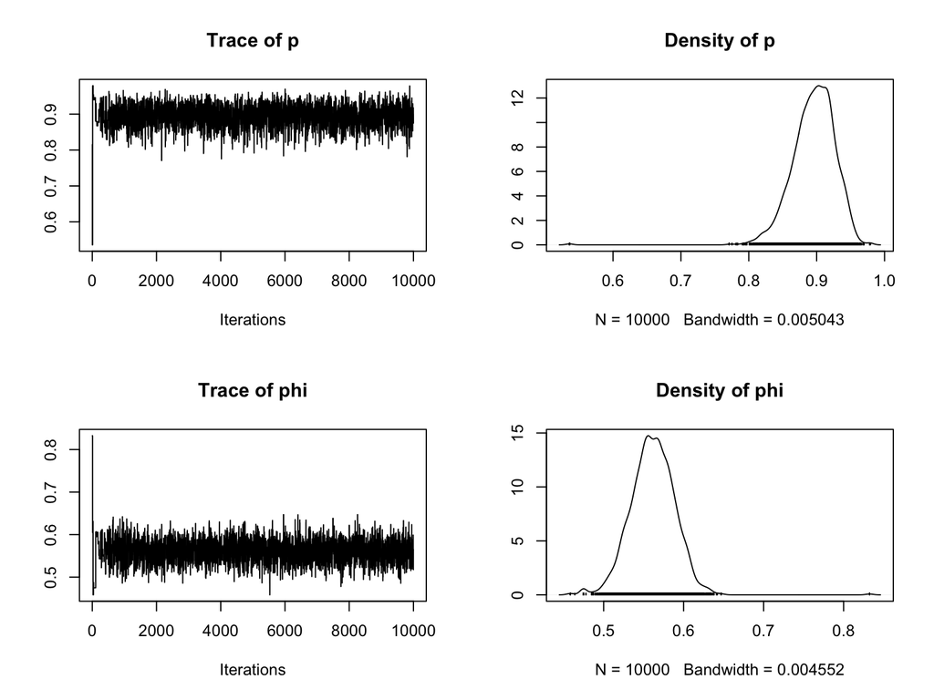

```r
plot(samples)
```

# Trying `dCJS` outside of a model

- It may help to explore how a distribution works outside of a model.
- You can use (and compile) it as a `nimbleFunction` in R.

```r
y <- c(1, 0, 1, 1, 0, 0)
probSurvive <- c(0.7, 0.6, 0.5, 0.4, 0.3)     # survival from t to t+1
probCapture <- c(NA, 0.5, 0.7, 0.5, 0.6, 0.4) # capture probability at t
dCJS_vv(y, probSurvive = probSurvive, probCapture = probCapture)
```

```
## [1] 0.0272244
```

```r
# (In a model, we need explicit indexing with [].  Outside of a model, we don't.)
c_dCJS_vv <- compileNimble(dCJS_vv)
```

```
## Compiling
##   [Note] This may take a minute.
##   [Note] Use 'showCompilerOutput = TRUE' to see C++ compilation details.
```

```r
c_dCJS_vv(y, probSurvive = probSurvive, probCapture = probCapture)
```

```
## [1] 0.0272244
```

# Look at `dCJS_vv` source code

You can look at a nimbleFunction like any other R function:

```r
dCJS_vv
```

```
## function (x, probSurvive, probCapture, len = 0, log = 0)
## {
##     if (len != 0) {
##         if (len != length(x))
##             nimStop("Argument len must match length of data, or be 0.")
##     }
##     if (length(probSurvive) < length(x) - 1)
##         nimStop("Length of probSurvive must be at least length of data minus 1.")
##     if (length(x) != length(probCapture))
##         nimStop("Length of probCapture does not match length of data.")
##     if (x[1] != 1)
##         nimStop("dCJS requires specifying first capture. x[1] must equal 1.")
##     probAliveGivenHistory <- 1
##     logProbData <- 0
##     if (len == 0) {
##         len <- length(x)
##     }
##     for (t in 2:len) {
##         probAlive <- probAliveGivenHistory * probSurvive[t -
##             1]
##         if (!is.na(x[t])) {
##             if (x[t] == 1) {
##                 probThisObs <- probAlive * probCapture[t]
##                 probAliveGivenHistory <- 1
##             }
##             else {
##                 probAliveNotSeen <- probAlive * (1 - probCapture[t])
##                 probThisObs <- probAliveNotSeen + (1 - probAlive)
##                 probAliveGivenHistory <- probAliveNotSeen/probThisObs
##             }
##             logProbData <- logProbData + log(probThisObs)
##         }
##     }
##     if (log) {
##         return(logProbData)
##     }
##     return(exp(logProbData))
## }
## <bytecode: 0x7f8ce55cf718>
## <environment: 0x7f8ce5575f98>
```

Or you can go to the [github repository](https://github.com/nimble-dev/nimbleEcology/tree/master/R)

# Debug `dCJS` in a model, as if you were trying to fix some bug

```r
# Run this code chunk only manually, since it has debugging in it.
Rmodel <- nimbleModel(dipper_code_dCJS, dipper_constants, dipper_data, dipper_inits())
Rmcmc <- buildMCMC(Rmodel)
debugonce(dCJS_ss)
Rmcmc$run(niter = 4)
```

# Variants of `dCJS_[s|v][s|v]`

Recall that `nimbleFunction`s require static typing.

Unfortunately:

- scalars are not automatically converted to length-one vectors.
- vectors are not automatically converted to single-row or single-column matrices.

This means we have implemented variants for `dCJS` (and others) depending on whether parameters are time-varying:

- `dCJS_ss` : both survival and capture are scalars (both time-independent, aka time-constant).
- `dCJS_sv` : survival is scalar (time-constant) but capture is vector (time-dependent).
- `dCJS_vs` : survival is vector (time-dependent) but capture is scalar (time-constant).
- `dCJS_vv` : both are time-dependent.

# Source code example: `dCJS_vv`

```r
dCJS_vv <- nimbleFunction(
  # It is assumed that the individual has already been captured.
  # Therefore, the first entry in x represents the first possible recapture event.
  # probSurvive[t] represents survival from t-1 to t.
  # probCapture[t] represents capture probability at time t.
  run = function(x = double(1),    ## standard name for the "data"
                 probSurvive = double(1),
                 probCapture = double(1),
                 len = double(0, default = 0),
                 log = integer(0, default = 0) ## required log argument
  ) {
    if (len != 0) {
      if (len != length(x)) stop("Argument len must match length of data, or be 0.")
    }
    if (length(probSurvive) < length(x) - 1)
      stop("Length of probSurvive must be at least length of data minus 1.")
    if (length(x) != length(probCapture)) stop("Length of probCapture does not match length of data.")
    if (x[1] != 1) stop("dCJS requires specifying first capture. x[1] must equal 1.")

    ## Note the calculations used here are actually in hidden Markov model form.
    probAliveGivenHistory <- 1
    ## logProbData will be the final answer
    logProbData <- 0
    if (len == 0) {  ## l<1 should not occur, but just in case:
      len <- length(x)
    }
    for (t in 2:len) {
      ## probAlive is P(Alive(t) | x(1)...x(t-1))
      ## probAliveGivenHistory is (Alive(t-1) | x(1)...x(t-1))
      probAlive <- probAliveGivenHistory * probSurvive[t - 1]
      if (!is.na(x[t])) {
        if (x[t] == 1) {
          ## ProbThisObs = P(x(t) | x(1)...x(t-1))
          probThisObs <- probAlive * probCapture[t]
          probAliveGivenHistory <- 1
        } else {
          probAliveNotSeen <- probAlive * (1 - probCapture[t])
          probThisObs <- probAliveNotSeen + (1 - probAlive)
          probAliveGivenHistory <- probAliveNotSeen / probThisObs
        }
        logProbData <- logProbData + log(probThisObs)
      }
    }
    if (log) {
      return(logProbData)
    }
    return(exp(logProbData))
    returnType(double())
  }
)
```

# Source code example: `rCJS_vv`

```r
rCJS_vv <- nimbleFunction(
  run = function(n = integer(),
                 probSurvive = double(1),
                 probCapture = double(1),
                 len = double(0, default = 0)) {
    if (n != 1) stop("rCJS only works for n = 1")
    if (len < 2)
      stop("len must be greater than 1.")
    if(length(probSurvive) != len - 1)
      stop("Length of probSurvive is not the same as len - 1.")
    if(length(probCapture) != len)
      stop("Length of probCapture is not the same as len.")
    ans <- numeric(length = len, init = FALSE)
    ans[1] <- 1
    alive <- 1
    if (len <= 0) return(ans)
    for (i in 2:len) {
      if (alive)
        alive <- rbinom(1, size = 1, prob = probSurvive[i - 1])
      if (alive) {
        ans[i] <- rbinom(1, size = 1, prob = probCapture[i])
      } else {
        ans[i] <- 0
      }
    }
    return(ans)
    returnType(double(1))
  }
)
```